# 20230123_CutandRun

# Log in to Elja

- Log in to Elja and navigate to `/hpcdata/Mimir/yourusername`.
- Make a new directory for logfiles, and then within that make a new directory for today’s date. Navigate into this directory.
- Type: `screen -L`. It will open a new screen for you and make a screenlog file that you can later download and view the text.
- Compute to a node using a command like this: `srun -N 2 -n 48 --pty /bin/bash`. Do not run anything before entering a node, it will slow down the whole Elja system otherwise and impact everyone.
- Now you can navigate into a folder with your files and run different programs.
- I first like to have each set of files for each sample in a separate folder, so that I can process them all at once using folder names. I use the following shell script for this:

```
#!/bin/sh

#Script to make folders based on file names and move files into the folders

for f in *.fastq.gz
do
  subdir=${f%%_L*}
  [ ! -d "$subdir" ] && mkdir -- "$subdir"
  mv -- "$f" "$subdir"
done
```

Save this file as a .sh file, i.e. “move_folders.sh” and then upload to Elja. Before running you need to make the script executable by using the following command:

```
chmod u+x move_folders.sh
```

Then you can run the script like this:

```
./move_folders.sh
```

- For quality checking you can run FastQC. I already trimmed by quality and trimmed adapter sequences during demultiplexing, so might not be necessary. If you want, here is the command to run fastQC on everything:

```
find . -maxdepth 1 -mindepth 1 -type d -exec bash -c "cd '{}' && pwd && fastqc *.fastq.gz" \;
```

## Alignment

We can use bowtie2 for aligning to the relevant genome. You can download ready-made bowtie2 indexes from [the Bowtie2 manual page](https://bowtie-bio.sourceforge.net/bowtie2/manual.shtml) or from [Illumina iGenomes](https://emea.support.illumina.com/sequencing/sequencing_software/igenome.html) or you can build your own. For the E. coli reference genome you should download Escherichia coli strain K12, MG1655 from iGenomes. Refer to the Bowtie2 manual for use if you want to build your own index. To download the E.coli index directly to Elja, you can use the following command:

```
wget http://igenomes.illumina.com.s3-website-us-east-1.amazonaws.com/Escherichia_coli_K_12_MG1655/NCBI/2001-10-15/Escherichia_coli_K_12_MG1655_NCBI_2001-10-15.tar.gz
```

Now we can start alignment. I would recommend having a couple of screens running at the same time, one for aligning to the E.coli genome and one to your organism, so that you can save time. Make sure that you remember the `screen -L` command in a new folder so that you will get a saved text output of the alignments. For the E. coli genome I ran the following shell script. You can do something similar for your organism. You might need to change the names of the fastq files if they are different, i.e. from a different run. Also, make sure to change the name of the `.sam` file so that you will have different file names for aligned E. coli reads and those of your organism.

```
#!/bin/sh


#Script to run bowtie2 on everything
find . -maxdepth 1 -mindepth 1 -type d -exec sh -c "cd '{}' && pwd && bowtie2 -p 24 -x /hpcdata/Mimir/kimberl/iGenomes/Escherichia_coli_K_12_MG1655/NCBI/2001-10-15/Sequence/Bowtie2Index/genome -1 '{$1}'_L004_R1_001.fastq.gz -2 '{$1}'_L004_R2_001.fastq.gz -S '{$1}'_e_coli.sam" \;
```

## Converting sam files to bam files

This is only really necessary for the sam files of alignments to your organism, as for E. coli we only really need to see the percent alignment. Save this as a shell script “.sh” file and run as previously.

```
#!/bin/sh

for i in `ls */*.sam | rev | cut -c 5- | rev | uniq` ;


do samtools view -@ 16 -bS ${i}.sam | samtools sort -T ${i} -O BAM -@ 16 -o ${i}.bam ;
pwd ;

done
```

# Getting percentage of E. Coli alignments

Before we can normalise our alignments to our organism of interest’s genome, we need to see the percent alignments for each sample to to E. Coli genome. To do this, I download the `screenlog.0` file from Elja and then copy-paste the text of all the E.coli alignments for all samples into a new text file. It should contain multiple alignments that look like this:

```
/hpcdata/Mimir/kimberl/20230116_Decode_CutandRun_decode_230116/20230118_fastq/20230116_temperature_cutandrun/NPC_rep1_32_H3K36_S48

44125126 reads; of these:

  44125126 (100.00%) were paired; of these:

    44013173 (99.75%) aligned concordantly 0 times

    109866 (0.25%) aligned concordantly exactly 1 time

    2087 (0.00%) aligned concordantly >1 times

    ----

    44013173 pairs aligned concordantly 0 times; of these:

      2219 (0.01%) aligned discordantly 1 time

    ----

    44010954 pairs aligned 0 times concordantly or discordantly; of these:

      88021908 mates make up the pairs; of these:

        88021306 (100.00%) aligned 0 times

        410 (0.00%) aligned exactly 1 time

        192 (0.00%) aligned >1 times

0.26% overall alignment rate
```

I saved this text file, then opened R for processing the info.

# Processing E. coli alignments in R

### Declaring libraries

```r
library(dplyr)
```

## Read in E Coli alignments

Prepare a text file only containing alignment text output from Bowtie2. Read this in and process as follows:

```r
E.coli.align <- read.delim("20230128_Ecoli_3rd_align.txt", header = FALSE)
E.coli = as.data.frame(E.coli.align[seq(1, nrow(E.coli.align), 16), ])
colnames(E.coli) <- c("Sample")
E.coli$read_number <- E.coli.align[seq(2, nrow(E.coli.align), 16), ]
E.coli$percent_align <- E.coli.align[seq(16, nrow(E.coli.align), 16), ]

E.coli$Sample <- gsub(".*n/","",E.coli$Sample)
Sample_name = substr(E.coli$Sample,1,nchar(E.coli$Sample)-4)

E.coli$read_number <- sub(" .*", "", E.coli$read_number)
E.coli$percent_align <- sub("%.*", "", E.coli$percent_align)
E.coli$percent_align <- as.numeric(E.coli$percent_align)
```

The normalisation factor is calculated as `1/(percent alignment to E. coli)`:

```r
E.coli$norm_factor <- 1/E.coli$percent_align
E.coli$Antibody <- sub(".*_", "", Sample_name)
write.csv(E.coli,"E_coli_align.csv", row.names = FALSE)
knitr::kable(E.coli)
```

| Sample | read_number | percent_align | norm_factor | Antibody |
| --- | --- | --- | --- | --- |
| HEK293_rep1_32_H3K36_S7 | 20264123 | 0.08 | 12.5000000 | H3K3 |
| HEK293_rep1_32_H3K4_S9 | 10689124 | 0.18 | 5.5555556 | H3K |
| HEK293_rep1_32_H3K9_S11 | 13402725 | 0.01 | 100.0000000 | H3K9 |
| HEK293_rep1_32_H4K20_S8 | 16466191 | 0.14 | 7.1428571 | H4K2 |
| HEK293_rep1_32_IgG_S12 | 5093904 | 1.56 | 0.6410256 | IgG |
| HEK293_rep1_37_H3K27_S4 | 18013488 | 0.02 | 50.0000000 | H3K2 |
| HEK293_rep1_37_H3K36_S1 | 13968492 | 0.07 | 14.2857143 | H3K3 |
| HEK293_rep1_37_H3K4_S3 | 12727432 | 0.11 | 9.0909091 | H3K |
| HEK293_rep1_37_H3K9_S5 | 16120268 | 0.01 | 100.0000000 | H3K |
| HEK293_rep1_37_H4K20_S2 | 17708914 | 0.09 | 11.1111111 | H4K2 |
| HEK293_rep1_37_IgG_S6 | 22064 | 0.27 | 3.7037037 | Ig |
| HEK293_rep2_32_H3K27_S23 | 48036459 | 0.04 | 25.0000000 | H3K27 |
| HEK293_rep2_32_H3K36_S20 | 69267134 | 0.05 | 20.0000000 | H3K36 |
| HEK293_rep2_32_H3K4_S22 | 864355 | 0.90 | 1.1111111 | H3K4 |
| HEK293_rep2_32_H3K9_S24 | 9974505 | 0.01 | 100.0000000 | H3K9 |
| HEK293_rep2_32_H4K20_S21 | 56500340 | 0.14 | 7.1428571 | H4K20 |
| HEK293_rep2_32_IgG_S25 | 1867654 | 3.61 | 0.2770083 | IgG |
| HEK293_rep2_32_SMYD5_S26 | 10292072 | 1.13 | 0.8849558 | SMYD5 |
| HEK293_rep2_37_H3K27_S16 | 39455351 | 0.07 | 14.2857143 | H3K27 |
| HEK293_rep2_37_H3K36_S13 | 37372705 | 0.04 | 25.0000000 | H3K36 |
| HEK293_rep2_37_H3K4_S15 | 14739031 | 1.84 | 0.5434783 | H3K4 |
| HEK293_rep2_37_H3K9_S17 | 24970351 | 0.01 | 100.0000000 | H3K9 |
| HEK293_rep2_37_H4K20_S14 | 37842935 | 0.16 | 6.2500000 | H4K20 |
| HEK293_rep2_37_IgG_S18 | 49179 | 0.40 | 2.5000000 | IgG |
| HEK293_rep2_37_SMYD5_S19 | 17016675 | 3.25 | 0.3076923 | SMYD5 |
| HEK293_rep3_32_H3K27_S37 | 28717753 | 0.05 | 20.0000000 | H3K27 |
| HEK293_rep3_32_H3K36_S34 | 50647266 | 0.04 | 25.0000000 | H3K36 |
| HEK293_rep3_32_H3K4_S36 | 19615221 | 1.61 | 0.6211180 | H3K4 |
| HEK293_rep3_32_H3K9_S38 | 38190985 | 0.01 | 100.0000000 | H3K9 |
| HEK293_rep3_32_H4K20_S35 | 52901663 | 0.18 | 5.5555556 | H4K20 |
| HEK293_rep3_32_IgG_S39 | 4855684 | 2.20 | 0.4545455 | IgG |
| HEK293_rep3_32_SMYD5_S40 | 164340 | 0.74 | 1.3513514 | SMYD5 |
| HEK293_rep3_37_H3K27_S30 | 56958893 | 0.05 | 20.0000000 | H3K27 |
| HEK293_rep3_37_H3K36_S27 | 28626973 | 0.10 | 10.0000000 | H3K36 |
| HEK293_rep3_37_H3K4_S29 | 11227375 | 3.13 | 0.3194888 | H3K4 |
| HEK293_rep3_37_H3K9_S31 | 30211029 | 0.01 | 100.0000000 | H3K9 |
| HEK293_rep3_37_H4K20_S28 | 42568717 | 0.22 | 4.5454545 | H4K20 |
| HEK293_rep3_37_IgG_S32 | 26177873 | 3.45 | 0.2898551 | IgG |
| HEK293_rep3_37_SMYD5_S33 | 85380 | 1.08 | 0.9259259 | SMYD5 |
| NPC_rep1_32_H3K27_S51 | 27854719 | 0.42 | 2.3809524 | H3K27 |
| HEK293_rep1_32_H3K27_S10 | 16995332 | 0.02 | 50.0000000 | H3K27 |

## Preparing bedGraph files for use in SEACR

We need to prepare bedGraph files that are normalised to the E.coli alignment. BedGraph files are the required input for SEACR and can later be used for visualisation. For this we need to make a shell script that reads in the csv file we prepared earlier and runs bedtools for each bam file. Remember to activate the bedtools module before starting.

```
#!/bin/sh


#Using awk to remove the quotation marks from the csv file
awk '{gsub(/"/,"")};1' E_coli_align.csv >  E_coli_align_clean.csv

INPUT=E_coli_align_clean.csv
OLDIFS=$IFS
IFS=','
[ ! -f $INPUT ] && { echo "$INPUT file not found"; exit 99; }


while read Sample read_number percent_align norm_factor Antibody
do
    echo "Name : $Sample"
    echo "Read number : $read_number"
    echo "Percentage alignment to E. coli : $percent_align"
    echo "Normalisation factor : $norm_factor"
    echo "Antibody : $Antibody"

  ls ${Sample}/

  bedtools genomecov -bg -pc -scale $norm_factor -ibam ${Sample}/${Sample}.bam > ${Sample}.norm.bedgraph


  echo -e "\n\n"

done < $INPUT
IFS=$OLDIFS
```

## SEACR for calling peaks

Move normalised bedgraph files into separate folders based on which antibody was used, then run the following script. Here we are trying two methods, calling peaks with the “non” setting to use the E.coli normalisation that we already performed, and with the “norm” method to run normalisation within SEACR. After comparing both outputs in IGV, it seems there isn’t a huge difference, so for H3K36me3, I will continue with the “non” normalised bed files of peaks.

```
#!/bin/sh

declare -a H3K36_files
for file in H3K36/*.bedgraph
do
    H3K36_files=("${H3K36_files[@]}" "$file")
done

declare -a IgG_files
for file in IgG/*.bedgraph
do
  IgG_files=("${IgG_files[@]}" "$file")
done


# Using [*]
echo -e '\nUsing [@] -----------------------------------'
for i in "${!H3K36_files[@]}"
do
    echo -e "Sample: *** $i ***"
    printf "%s matches with %s\n" "${H3K36_files[i]}" "${IgG_files[i]}"

    bash SEACR_1.3.sh ${H3K36_files[i]} ${IgG_files[i]} non stringent ${H3K36_files[i]:0:27}

    bash SEACR_1.3.sh ${H3K36_files[i]} ${IgG_files[i]} norm stringent ${H3K36_files[i]:0:27}_norm

    echo -e "\n\n"


done
```

## Comparing samples with DiffBind

```r
library(DiffBind)
```

Reading in peaksets

```r
NPC_H3K36_bg <- paste0("Bedgraph files/",list.files("Bedgraph files/", pattern = "*H3K36*"))
bamReads <- paste0("Bam files/NPC_H3K36_bam/",grep(list.files(path="Bam files/NPC_H3K36_bam/"), pattern='bai', invert=TRUE, value=TRUE))
SampleID <- substr(list.files("Bedgraph files/", pattern = "*H3K36*"), 1, 21)
Peaks <- paste0("NPC_SEACR_bed_files/Non_norm/", intersect(list.files("NPC_SEACR_bed_files/Non_norm/", pattern = "H3K36"),
                                                           list.files("NPC_SEACR_bed_files/Non_norm/", pattern = "rep1|rep2")))

sample.sheet <- as.data.frame(cbind(SampleID,bamReads, Peaks))
sample.sheet$Condition <- c(32, 37, 32, 37)
sample.sheet$Replicate <- c(1,1,2,2)
sample.sheet$PeakCaller <- rep(c("bed"), times = 4)
sample.sheet$bamControl <- paste0("Bam files/NPC_IgG_bam/", grep(list.files(path = "Bam files/NPC_IgG_bam/"), pattern = "bai", invert =TRUE, value = TRUE))
sample.sheet$Control_ID <- rep(c("IgG"), times=4)
sample.sheet <- sample.sheet[,c(1,4,5,2,8,7,3,6)]

H3K36me3.dba <- dba(sampleSheet=sample.sheet)
plot(H3K36me3.dba)

H3K36me3.dba<- dba.count(H3K36me3.dba)
plot(H3K36me3.dba)


H3K36me3.dba <- dba.normalize(H3K36me3.dba)
norm <- dba.normalize(H3K36me3.dba, bRetrieve = TRUE)

dba.plotPCA(H3K36me3.dba,  attributes=DBA_CONDITION, label=DBA_ID)

#Setting 37°C as the baseline condition
H3K36me3.dba <- dba.contrast(H3K36me3.dba, reorderMeta=list(Condition="37"), minMembers = 2)
H3K36me3.dba

H3K36me3.dba <- dba.analyze(H3K36me3.dba)
plot(H3K36me3.dba, contrast=1)

#Retreiving the differential peaks
H3K36me3.dba_diffPeaks <- dba.report(H3K36me3.dba)
H3K36me3.dba_diffPeaks

dba.plotMA(H3K36me3.dba)
dba.plotVolcano(H3K36me3.dba)

H3K36me3.dba_diffPeaks.df <- as.data.frame(H3K36me3.dba_diffPeaks)
write.table(H3K36me3.dba_diffPeaks.df, file = "H3K36me3_diffPeaks.bed", row.names=FALSE, sep="\t")
write.csv(H3K36me3.dba_diffPeaks.df, file = "H3K36me3_diffPeaks.csv", row.names=FALSE)
```

## Annotating peaks

```r
library(ChIPseeker)
library(TxDb.Hsapiens.UCSC.hg38.knownGene)
library(org.Hs.eg.db)
```

```
## >> loading peak file...               2023-01-31 3:48:36 PM
## >> preparing features information...      2023-01-31 3:48:36 PM
## >> identifying nearest features...        2023-01-31 3:48:40 PM
## >> calculating distance from peak to TSS...   2023-01-31 3:48:42 PM
## >> assigning genomic annotation...        2023-01-31 3:48:42 PM
## >> adding gene annotation...          2023-01-31 3:49:22 PM
```

```
## >> assigning chromosome lengths           2023-01-31 3:49:23 PM
## >> done...                    2023-01-31 3:49:23 PM
```

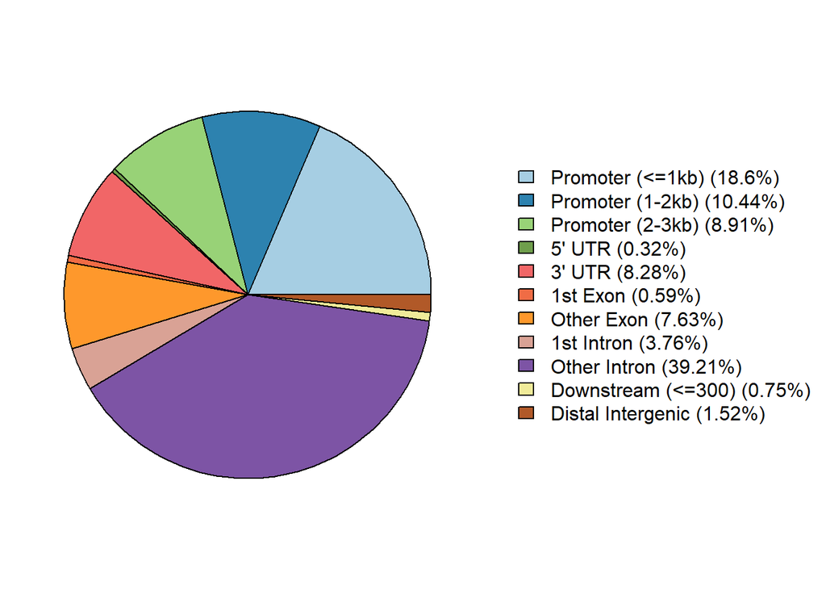

```r
txdb <- TxDb.Hsapiens.UCSC.hg38.knownGene

anno_function <- function(bedfile) {
  cuttag_anno <- annotatePeak(bedfile, TxDb = txdb, annoDb="org.Hs.eg.db")
  anno_df <- as.data.frame(cuttag_anno)
  plotAnnoPie(cuttag_anno)
  return(anno_df)
}

H3K36me3_NPC_anno <- anno_function("H3K36me3_diffPeaks.bed.txt")
```

## Obtaining bed file of TSSs for all hg38 genes from Txdb

```r
hg38.genes = genes(txdb, columns=c("tx_id", "tx_name","gene_id"))
```

```
##   1613 genes were dropped because they have exons located on both strands
##   of the same reference sequence or on more than one reference sequence,
##   so cannot be represented by a single genomic range.
##   Use 'single.strand.genes.only=FALSE' to get all the genes in a
##   GRangesList object, or use suppressMessages() to suppress this message.
```

```r
hg38genes.tss <- as.data.frame(hg38.genes)

write.table(hg38genes.tss[,c(1:5)], file = "hg38_genes_tss.bed", quote = FALSE, row.names=FALSE, col.names = FALSE, sep="\t")
```

Now on Elja, we can compute a matrix using deepTools. First merge bam files for the 2 replicates with samtools:

```
samtools merge NPC_rep1_rep2_32_H3K36_merged.bam NPC_rep1_32_H3K36_S48.bam NPC_rep2_32_H3K36_S62.bam

samtools merge NPC_rep1_rep2_37_H3K36_merged.bam ../../NPC_rep1_37_H3K36_S41/NPC_rep1_37_H3K36_S41.bam  ../../NPC_rep2_37_H3K36_S55/NPC_rep2_37_H3K36_S55.bam

#Index bam files
samtools index *.bam
```

Now using deepTools, convert merged indexed bam files to bigWig files that are normalised to genome coverage depth:

```
bamCoverage --bam NPC_rep1_rep2_32_H3K36_merged.bam -o NPC_rep1_rep2_32_H3K36_merged_depthnorm.bw -p max --binSize 5 --normalizeUsing RPGC --effectiveGenomeSize  2913022398 --ignoreForNormalization chrX --extendReads
bamCoverage --bam NPC_rep1_rep2_37_H3K36_merged.bam -o NPC_rep1_rep2_37_H3K36_merged_depthnorm.bw -p max --binSize 5 --normalizeUsing RPGC --effectiveGenomeSize  2913022398 --ignoreForNormalization chrX --extendReads
```

Again with deepTools, compute matrix to plot signal intensity over gene regions, with genes scaled to be same length in plot, from transcription start site (TSS) to transcription end site (TES). First, we will plot over genes with unscaled regions 2kb upstream of TSS and 2kb downstream of TES added into the plot:

```
computeMatrix scale-regions -o NPC_H3K36me3_32_37_overWholeGenes_matrix -S NPC_rep1_rep2_32_H3K36_merged_depthnorm.bw NPC_rep1_rep2_37_H3K36_merged_depthnorm.bw -R hg38_genes_tss.bed -p 48 --samplesLabel 32°C 37°C --missingDataAsZero --skipZeros -b 2000 -a 2000

plotHeatmap -m NPC_H3K36me3_32_37_overWholeGenes_matrix -o NPC_H3K36me3_32_37_over_WholeGenes.pdf
```

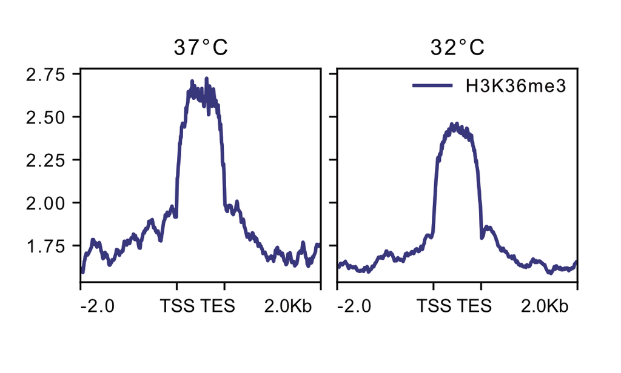

```r
knitr::include_graphics("NPC_H3K36me3_32_37_profile_over_WholeGenes_2kb_updown.png")
```

Now, we do the same, but only plot the scaled gene regions:

```
computeMatrix scale-regions -o NPC_H3K36me3_32_37_overWholeGenes_final_matrix -S NPC_rep1_rep2_32_H3K36_merged_depthnorm.bw NPC_rep1_rep2_37_H3K36_merged_depthnorm.bw -R hg38_genes_tss.bed -p 48 --samplesLabel 32°C 37°C --missingDataAsZero --skipZeros

plotHeatmap -m NPC_H3K36me3_32_37_overWholeGenes_final_matrix -o NPC_H3K36me3_32_37_over_WholeGenes_final.pdf
```

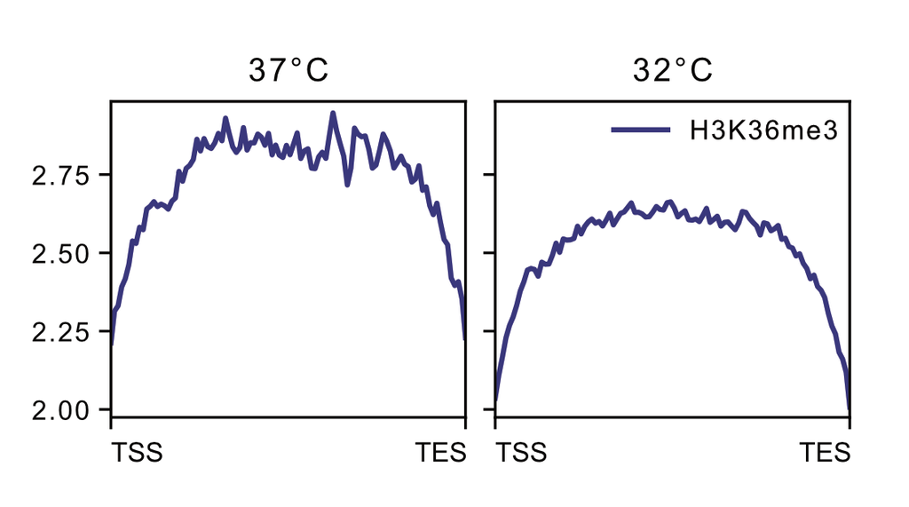

```r
knitr::include_graphics("NPC_H3K36me3_32_37_profile_over_WholeGenes.png")
```